# Tagged Tweets Analysis

## Helper Functions

```python
# Helper function to convert dataframe to plotly
def df_to_plotly(df):
    return {'z': df.values.tolist(),
            'x': df.columns.tolist(),
            'y': df.index.tolist()}

def tweets_performance(grouped_df, worst = True, best = False, n = 6):

    if worst == True and best == False:

        tweets_series = grouped_df.correct_preds_percent.sort_values().tail(n)

    elif best == True and worst == False:

        tweets_series = grouped_df.correct_preds_percent.sort_values().tail(n)

    elif best == True and worst == True:
        print("Can't have worst and best set to true!")
        return

    elif best == False and worst == False:
        print("Can't have worst and best set to False!")
        return

    else:

        print("Call Gandalf, an error has happened")



    # Best Tweets indices

    tweets_df = grouped_df.loc[tweets_series.index.to_list(), 'text'].reset_index(name = 'text')

    tweets_df.insert(1, 'percent_score', tweets_series.values)

    return tweets_df
```

```python
import pandas as pd
import seaborn as sns
import plotly.io as pio
import plotly.graph_objects as go
import matplotlib as mpl
import matplotlib.pyplot as plt


sns.set(rc={'figure.figsize':(10,7)})
pd.set_option('display.max_colwidth', None)

mpl.rcParams['figure.dpi'] = 100
```

```python
df = pd.read_csv('../reports/ml_models_performance_analysis/report-2020_06_28_072853-148t-analysis.csv')
df.rename(columns = {'Unnamed: 0':'tweet_index'}, inplace = True)
```

## Overall tweet performance

These tweets are the ones that have the biggest ammount of incorrect predictions.

What is the overall number of correct predictions? Correct predictions is defined as the sum of the pred_cols. There is a total of 7 tags

and theres is a total of 13 variants of models

- 0.98% of models correctly predicted 4 out of 7 labels
- 0.89% of models correctly predicted 5 out of 7 labels
- 0.59% of models correctly predicted 6 out of 7 labels
- 0.19% of models correctly predicted 7 out of 7 labels

```
1.0%    of models correctly predicted 1 out of 7 labels
1.0%    of models correctly predicted 2 out of 7 labels
1.0%    of models correctly predicted 3 out of 7 labels
0.981%    of models correctly predicted 4 out of 7 labels
0.889%    of models correctly predicted 5 out of 7 labels
0.597%    of models correctly predicted 6 out of 7 labels
0.197%    of models correctly predicted 7 out of 7 labels
```

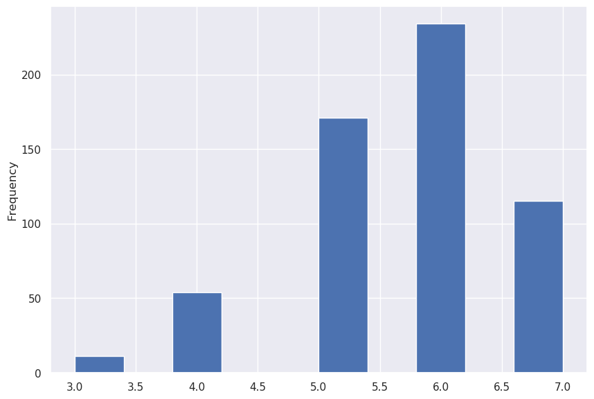

```python
## 45 unique tweets
# df.tweet_index.value_counts().sort_index()

total_correct_preds = df.loc[:, [
 'assert_circumstantial-information',
 'assert_electricity',
 'assert_gasoline',
 'assert_social-report',
 'assert_twitter-account',
 'assert_water',
 'assert_gas']].sum(axis=1)

df['total_correct_preds'] = total_correct_preds

df.total_correct_preds.plot.hist()

for i in range(df.total_correct_preds.max()):
    print(  f'{round((df.total_correct_preds >= i+1 ).sum() / df.shape[0], 3)}%\
    of models correctly predicted {i+1} out of {df.total_correct_preds.max()} labels'
       )
# groupby_tweet.head()
```

### Performance by tweet across models

##### Number of models that correctly predicted the label

Now the dataframe is going to be grouped by tweets. There is a total of 45 unique tweets in the dataframe.

For the following analysis, the raw amount of matched tweets is going to be analyzed.

There is a total of 13 model variants. Thus, if a tweet correctly predicted a label in all models, it will contain 13 in the grouped dataframe.

##### Findings

- Top 3 most inaccurate labels in descending order
  - assert_social-report
  - assert_circumstantial-information
  - assert_twitter-account

##### Hypotheses

- There is a model that correctly predicts all the labels in at least 1 tweet.
- Probably social report label performance varies a lot because its tokens is too generic / varies a lot / is difficult to extract a pattern.
- Tweets that incorrectly predict a twitter account is because
  - There is a flaw in the labeling process. I.e, They are tagged all together.
  - Commonly these tweets don't have a twitter account.
- Labels in general fail to be predicted because their representation vary a lot. I.e., public services are commonly represented in hashtags.
  - However how this can be explained by twitter_account? All twitter accounts follow the pattern @twitter-account
- Next step is to inspect closer how tweets fail to predict the labels. Goal: Find possible reasons why this is happening.

```python
# Copy original df to groupby
groupby_tweet = df.copy()

# Set original tweet index as the new dataframe's index
groupby_tweet.set_index('tweet_index', inplace = True)

# Group by text
groupby_tweet = groupby_tweet.groupby('text', as_index= False).sum()

# Sort index in ascending order
groupby_tweet.sort_index(ascending = True, inplace = True)

groupby_tweet_assert = groupby_tweet[[
                            'assert_circumstantial-information',
                             'assert_electricity',
                             'assert_gasoline',
                             'assert_social-report',
                             'assert_twitter-account',
                             'assert_water',
                             'assert_gas']].copy()


# Instantiate plotly object
fig = go.Figure(data=go.Heatmap(
    df_to_plotly(groupby_tweet_assert),
    colorbar=dict(title='Number of models that <br> correctly predicted the label'),
    colorscale="BuPu"
    )
)

# Change layout
fig.update_layout(
    title='''<b>Performance by tweet</b>
                <br>
                <i>The darker, the better performance</i>
            ''',
    xaxis_title="Labels",
    yaxis_title="Tweets ID",
    font=dict(
        family="Arial",
        size=14,
        color="black"
    ),
    yaxis = dict(dtick = 1),
    width=1200,
    height=800,
)

## Snippet save plot as HTML, we can implement this if we pass this to a class.
# pio.write_html(fig, f'test.html')

## Show the plot and render it through the notebook,
    ## important to display the plot when exporting the notebook as html
fig.show(renderer="notebook")


# for index, item in groupby_tweet_assert.mean().sort_values(ascending = True).iteritems():
#     print (f'''{index} label correctly predicted (avg) in {round(item,0)} / {groupby_tweet_assert.max().max()} models \n {'-'* 100}''')
```

[interactive chart not shown]

## Tweets fail to predict labels

Inspect closer how tweets fail to predict the labels. Goal: Find possible reasons why this is happening. Note: use the transpose

| Index | Percentage Score | Text |
| --- | --- | --- |
| 40 | 52.7 % | valera estado trujillo ya cuenta con servicio electrico #sinluz falta el agua el gas la gasolina la seguridad la salud educacion transporte pero por algo se empieza \n |
| 15 | 53.8 % | @hidrocaribe @evelynb_vasquez @mppaaguas @hidrovenca @maduro_en @vicevenezuela @nestorreverol @luisjmarcano @drodriguezven lunes 04nov hora 3 50pm #sinagua; los tronconales mcpo bolivar pqa el carmen … |
| 41 | 63.7 % | vivo en #yaracuy y tengo un mes #singas cuanto tiempo tienen ustedes \n |
| 3 | 63.7 % | #ahora estaciones esperando por la cisterna en pto ordaz morochas av atlantico la de los olivos villa africana las americas subiendo a alta vista y la que esta frente a c alta vista 2 #singasolina #gu… |
| 2 | 64.8 % | #28dic #singasolina #ciudadguayana deberian ver las colas aqui haciendo una desde las 6 de la tarde el viernes 27 para equipar el lunes 30 ya hay aproximadamente 300 carros y sigu \n |

| index | percent_score | text |
| --- | --- | --- |
| 17 | 93.4 % | @willy_casanova @nicolasmaduro que paso con hidrolago no bombea agua en cuatricentenario desde hace 12 dias los cortes #sinluz estan a la orden del dia necesitamos agua por favor\n |
| 39 | 93.4 % | usuarios informan que estan sin electricidad desde la 1 pm de este #19nov zonas de los estados falcon guarico aragua trujillo zulia miranda y yaracuyayudenos a informar indicando lugar sitio y la hora… |
| 44 | 93.4 % | ya van casi tres horas #sinluz en el rectorado uc la lluvia paro ya el sol seco las calles pero la incapacidad socialista sigue #socialismoesmiseria #chavismoescrimen #madurismoesestupidez #lacavaesco… |
| 38 | 94.5 % | temperaturas extremas en el estado zulia y el gobernador @omarprietogob sigue sin anunciar hasta cuando seran los cortes inhumanos el pueblo zuliano sufre sea responsable gobernador no ignore al puebl… |
| 33 | 97.8 % | maracaibo presenta nuevo apagon que afecta a decenas de familias y enfermos en los ya deterioradas hospitales la culpa no es de la vaca es del chavismo revolucion destructora #crisis #zulia #mcbo #sin… |

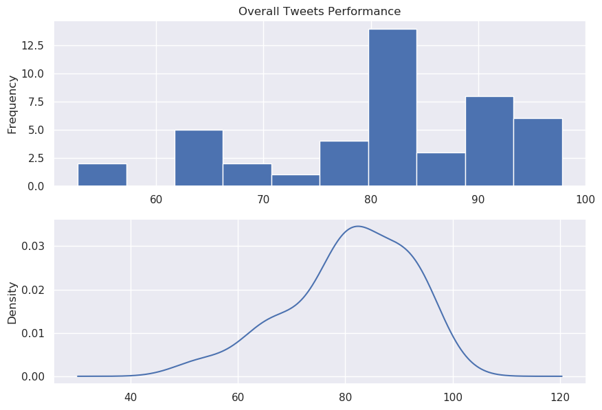

```python
groupby_tweet.total_correct_preds
# 13
groupby_tweet.columns

total_labels =  len(['assert_circumstantial-information', 'assert_electricity',
                   'assert_gasoline', 'assert_social-report', 'assert_twitter-account',
                   'assert_water', 'assert_gas'])
# total_models =

total_models = df.model_name.value_counts().shape[0]

max_total_preds_score = total_labels * total_models

(round(groupby_tweet.total_correct_preds / max_total_preds_score, 3) * 100).value_counts()


groupby_tweet['correct_preds_percent'] = round(groupby_tweet.total_correct_preds / max_total_preds_score, 3) * 100

groupby_tweet.correct_preds_percent.value_counts().sort_index()

fig, axes = plt.subplots(nrows = 2)

groupby_tweet.correct_preds_percent.plot.hist(title = 'Overall Tweets Performance' ,ax=axes[0] )
groupby_tweet.correct_preds_percent.plot.kde(ax=axes[1])

plt.show()
```

### Performance by Tweets

```python
# # Top 6 worst tweets
worst_tweets = tweets_performance(groupby_tweet, best = False, worst = True, n = 6)
# worst_tweets # Dataframe
# print(worst_tweets['index'].to_list()) # Indices

# # Top 6 best tweets
best_tweets = tweets_performance(groupby_tweet, best = True, worst = False, n = 6)
# best_tweets
# print(best_tweets['index'].to_list()) # Indices
```